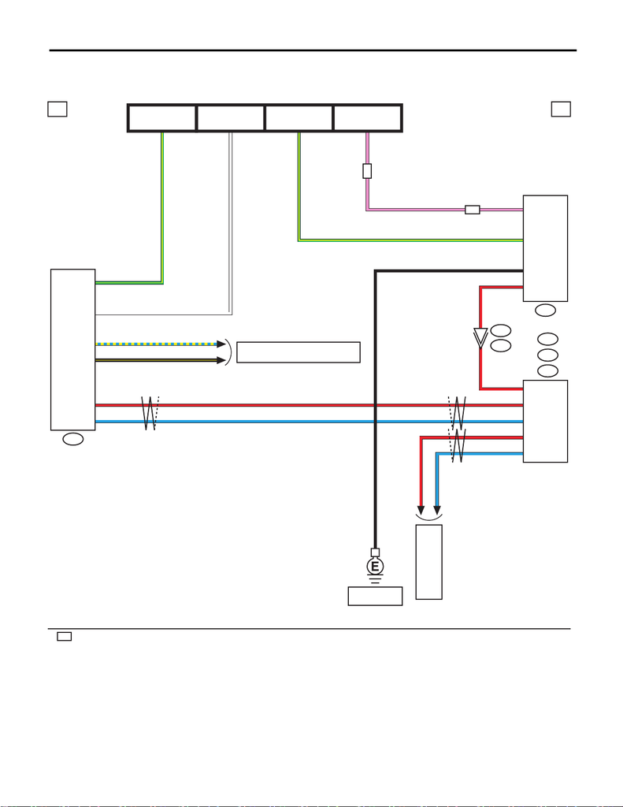

WI-403

Tire Pressure Monitoring System

WIRING SYSTEM

55.Tire Pressure Monitoring System

A: WIRING DIAGRAM

WI-44593

1

C: i84

B: B281

D: i171

B

B40

OP

1

i102

3

R167

OP

OP

R

L

6

14

B/Y4

15

W16

G/Y8

G/Y

W

G/Y

P

L B28

R B20

R D11

R11

B5

G/Y 4

P6

L C35

R

L

R

C27

R

R

2

3

2

REF. TO ENGINE ELECTRICAL SYSTEM

[1g] [2g] [3f] [4f]

REF. TO CAN

COMMUNICATION

SYSTEM [b]

FB-11

F/B FUSE NO. 15

(B)

FB-31

F/B FUSE NO. 4

(IG)

MB-27

M/B FUSE NO. 13

(B)

: WITHOUT PUSH BUTTON START

FB-32

F/B FUSE NO. 4

(IG)

REF. TO GND

[f]

DATA LINK

CONNECTOR

BODY

INTEGRATED

UNIT

: ENGINE TYPE FA : B/R

ENGINE TYPE EJ : B/W

: WITHOUT PUSH BUTTON START : TPMS & KEYLESS ENTRY CM

WITH PUSH BUTTON START : TPMS CM

: WITHOUT PUSH BUTTON START : R221

WITH PUSH BUTTON START : R211

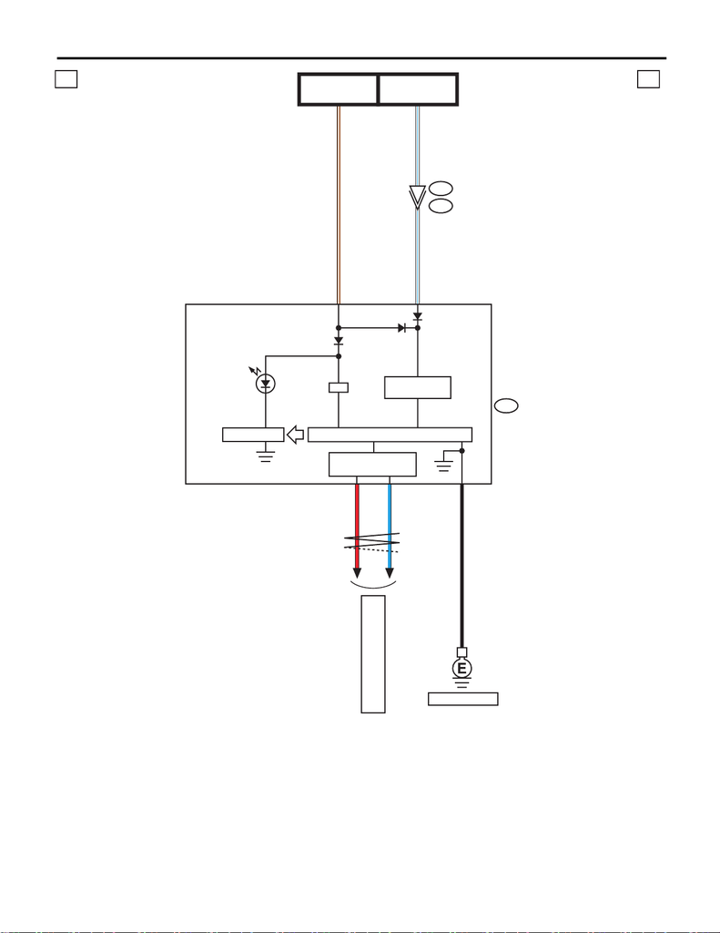

WI-404

Tire Pressure Monitoring System

WIRING SYSTEM

WI-44594

i10

3

b b

i229

B551

BR/W

W/L

38

B

40 W/L

20 BR/W

B

R33

L32

I/F

W/L

W/L

POWER SUPPLY

CIRCUIT

DRIVE CIRCUIT

REF. TO CAN COMMUNICATION

SYSTEM [b]

TIRE INFLATION

PRESSURE

CAN TRANSCEIVER &

RECEIVER

MICRO COMPUTER

FB-18

F/B FUSE NO. 7

(B)

FB-12

F/B FUSE NO. 2

(IG)

REF. TO GND [e]

COMBINATION

METER

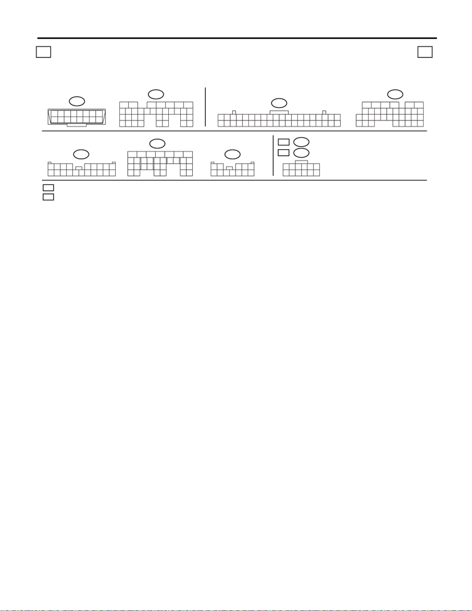

WI-405

Tire Pressure Monitoring System

WIRING SYSTEM

R221

R211

9

10

78

65341

2

WP

:

OP

:

OP

WP

WI-44595

c c

i229

12 345

6789

10 11 12

i10

11 12

9

10

7856341

2

18

20

21 22 23 24 26

25

27 28 29 30 31 32 33 34 35 36 37 38 39 40

17

B40

(B)

1

9

8

16

2

10

7

15

3

11

6

14

4

12

5

13

B281B:

5672134

29

10 11 12 13 14 15

2524

16

30

98

17 18 19

20

28

21 22 23

3231

26 27

33 34 35

i84C:

19

18

21

20

2322 24 25 26

17

1

23

4

56

27

28 29 30

31 32 33 34 35

798

151413121110 16

89

19 20

1234 567

10 11 12 13 14 15 16 17 18

i102

i171D:

19

18

20 21

22

23

26

24

25

27

28 29

30 31

98

15

1413121110

17

16

1234567

: WITHOUT PUSH BUTTON START

: WITH PUSH BUTTON START

LIST OF CONNECTORS